# Assignment-B1-2

2023-11-03

#Stats 545B Assignment B-1

The code and explanations following are intended to fulfil requirements for Stats545B assignment B-1.

*Packages to load*

```r
library(tidyverse)
library(testthat)
library(dplyr)
library(gapminder)
library(digest)
library(palmerpenguins)
library(commonmark)
library(devtools)
library(roxygen2)
library(tools)
```

###Excercise 1: Make a Function

This is a simple function designed to create a bar graph for in order to quickly get compare counts for a variable of interest.

```r
#' Create a Bar Graph
#'
#' @param df The dataset containing your variable of interest
#' @param x Your variable of interest to be graphed
#'
#' @return A horizontal bar graph
#'
#' @examples
bar_function <- function(df, x){
  ggplot(df, aes(x)) +
  geom_bar(fill = "azure4") +
  coord_flip() +
  theme_minimal()
}
```

###Exercise 3: Include Examples

#####Example 1:

Here is an example using the palmerspenguins::penguins dataset. Here, I specify the df as penguins, then x as penguins$species. The result is a bar graph showing counts of species fromt the penguins dataset.

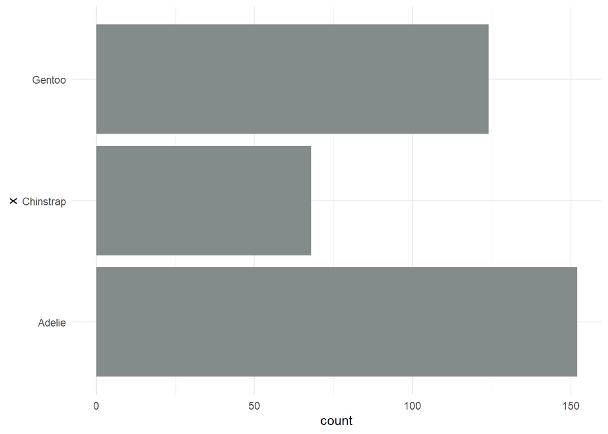

```r
bar_function(penguins, penguins$species)
```

#####Example 2:

Here is an example using the gapminder::gapminder dataset. In this example, df has been specified as gapminder, while x has been specified at gapminder$continent. The resulting bar graph displays count for continents.

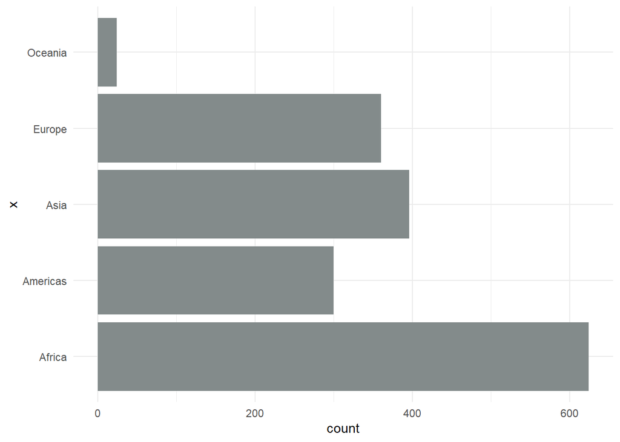

```r
bar_function(gapminder, gapminder$continent)
```

###Exercise 4: Test the Function

Write formal tests for your function. You should use at least three non-redundant uses of an expect_() function from the testthat package, and they should be contained in a test_that() function (or more than one). They should all pass.

Example of non-redundant inputs:

```
Vector with no NA’s
Vector that has NA’s
Vector of a different type (if relevant)
Vector of length 0, like numeric(0).
```